# Descriptive Statistics on Prices of Women’s Shoes

Asela Dassanayake

1/15/2020

## The dataset used

To run the lab, I have used kaggle’s Women’s Shoe Prices dataset. This dataset includes a list of 10,000 women’s shoes and the prices at which they are sold.

[Link to the dataset](https://www.kaggle.com/datafiniti/womens-shoes-prices)

## Load the required libraries and the datasets

```r
# load the required libraries
library(ggplot2)
setwd("D:/mytrainings/statistics/learningrinaustin")

# load the datasets
womens_shoes = read.csv(file = "datasets/womens-shoes-prices/Datafiniti_Womens_Shoes.csv")
```

## Structure of the dataset

```r
str(womens_shoes)
```

```
## 'data.frame':    10000 obs. of  34 variables:
##  $ ï..id              : Factor w/ 653 levels "AV-9hndsuC1rwyj_g2bb",..: 390 456 456 471 445 418 470 470 404 391 ...
##  $ dateAdded          : Factor w/ 440 levels "2015-05-04T12:13:08Z",..: 1 87 87 89 89 41 66 66 39 40 ...
##  $ dateUpdated        : Factor w/ 495 levels "2018-01-01T05:51:15Z",..: 210 8 8 20 71 495 494 494 10 229 ...
##  $ asins              : Factor w/ 2 levels "","B016GSDNVM": 1 1 1 1 1 1 1 1 1 1 ...
##  $ brand              : Factor w/ 129 levels "2 lips too","a2 by aerosoles",..: 74 72 72 72 72 107 72 72 72 72 ...
##  $ categories         : Factor w/ 207 levels "Clothing,Shoes,Baby & Kids Shoes,Girls' Boots,Women's Shoes,All Women's Shoes,Girls' Shoes",..: 5 19 19 10 10 50 34 34 3 29 ...
##  $ primaryCategories  : Factor w/ 2 levels "Shoes","Shoes,Shoes": 1 1 1 2 1 1 1 1 1 1 ...
##  $ colors             : Factor w/ 220 levels "","Angora,Light Porcelain Blue",..: 189 123 123 14 123 95 148 148 170 93 ...
##  $ dimension          : Factor w/ 20 levels "","10.00 in x 8.00 in x 4.00 in",..: 1 1 1 17 17 14 1 1 1 1 ...
##  $ ean                : num  NA 3.4e+10 3.4e+10 3.4e+10 3.4e+10 ...
##  $ imageURLs          : Factor w/ 653 levels "https://content.backcountry.com/images/items/900/ADA/ADA006K/BLAA.jpg,https://content.backcountry.com/images/it"| __truncated__,..: 163 136 136 172 148 158 142 142 133 192 ...
##  $ keys               : Factor w/ 653 levels "033977045903,muklukswomensdawnsuedescuffslipper/553409417,mukluks/00173660016,0033977045903",..: 527 521 521 1 522 2 651 651 520 524 ...
##  $ manufacturer       : Factor w/ 20 levels "","ASICS","Brinley Co",..: 1 12 12 12 1 19 1 1 14 14 ...
##  $ manufacturerNumber : Factor w/ 252 levels "","0015589605-S",..: 39 7 7 8 9 3 2 2 32 33 ...
```

[output cut: 20 more lines]

The dataset has 10,000 observations on 34 variables.

## Understanding the central tendancy and the spread of the data

I have considered the prices.amountMax to run descriptive statistics.

```r
# understand the central tendancy and the spread of the prices amountmax
mean(womens_shoes$prices.amountMax)
```

```
## [1] 69.22354
```

```r
median(womens_shoes$prices.amountMax)
```

```
## [1] 64.99
```

```r
sd(womens_shoes$prices.amountMax)
```

```
## [1] 19.48729
```

```r
IQR(womens_shoes$prices.amountMax)
```

```
## [1] 20
```

```r
summary(womens_shoes$prices.amountMax)
```

```
##    Min. 1st Qu.  Median    Mean 3rd Qu.    Max.
##    5.87   59.99   64.99   69.22   79.99  359.95
```

## Visualizing the distribution of the data through plotting

As a general practice, apart from obtaining numeric measures, I also visualize the distribution of the dataset as this will enable me to gain different perspectives quickly.

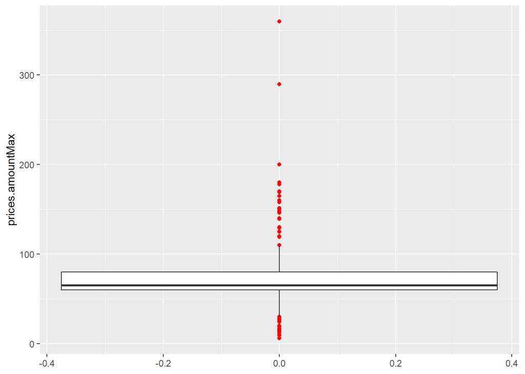

```r
# draw a box plot
ggplot(data = womens_shoes, aes(y=prices.amountMax)) +
  geom_boxplot(outlier.colour = "red")
```

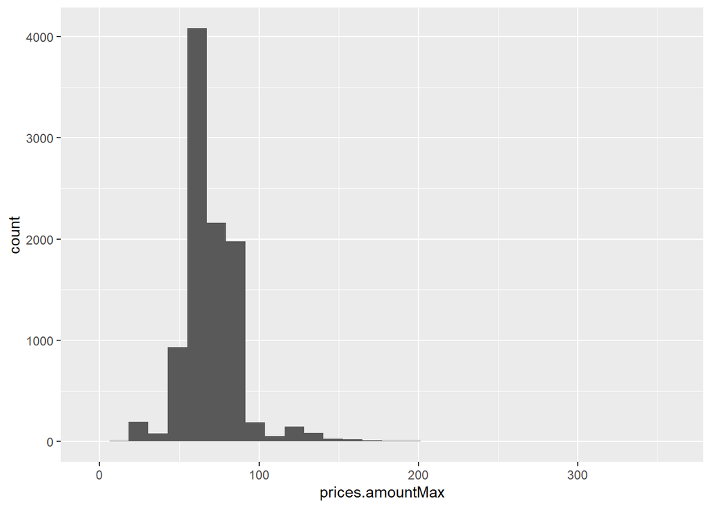

```r
# draw a histogram plot
ggplot(data = womens_shoes, aes(x=prices.amountMax)) +
  geom_histogram()
```

## Discussion

Based on the numeric measures, it was clear that shoe prices were right-skewd as the mean was higher than the median. With Prices ranging from a minimum of 5.87 to a maximum of 359.95 as well as the middle 50% data points ranging within a narrow window of 59.99 to 79.99, I was able to understand that the dataset could have quite a lot of outliers maninly on the higher side.

By plotting the distribution on a box plot as well as on a histrogram, I was able to clearly visualize what the numeric measures were suggesting – The box plot clearly shows the many outliers; The histogram clearly shows the long tail towards the expensive shoes as well as the right-skewness of the distribution.